# Risk Factor Analysis

## Outcome Variable

**Outcome Variable:** dead

## Predictor Variables

**Intervention Variable:** ever_stunted024

**Adjustment Set:**

- sex
- arm
- brthmon
- vagbrth
- hhwealth_quart
- W_mage
- W_mhtcm
- W_mwtkg
- W_mbmi
- W_meducyrs
- W_feducyrs
- W_nrooms
- W_parity
- impsan
- safeh20
- delta_vagbrth
- delta_hhwealth_quart
- delta_W_mage
- delta_W_mhtcm
- delta_W_mwtkg
- delta_W_mbmi
- delta_W_meducyrs
- delta_W_feducyrs
- delta_W_nrooms
- delta_W_parity
- delta_impsan
- delta_safeh20

## Stratifying Variables

The analysis was stratified on these variable(s):

- studyid
- country

## Data Summary

| studyid | country | ever_stunted024 | dead | n_cell | n | outcome_variable |
| --- | --- | --- | --- | --- | --- | --- |
| Burkina Faso Zn | BURKINA FASO | 0 | 0 | 4568 | 7164 | dead |
| Burkina Faso Zn | BURKINA FASO | 0 | 1 | 22 | 7164 | dead |
| Burkina Faso Zn | BURKINA FASO | 1 | 0 | 2557 | 7164 | dead |
| Burkina Faso Zn | BURKINA FASO | 1 | 1 | 17 | 7164 | dead |
| EE | PAKISTAN | 0 | 0 | 41 | 379 | dead |
| EE | PAKISTAN | 0 | 1 | 0 | 379 | dead |
| EE | PAKISTAN | 1 | 0 | 334 | 379 | dead |
| EE | PAKISTAN | 1 | 1 | 4 | 379 | dead |
| GMS-Nepal | NEPAL | 0 | 0 | 249 | 698 | dead |
| GMS-Nepal | NEPAL | 0 | 1 | 3 | 698 | dead |
| GMS-Nepal | NEPAL | 1 | 0 | 441 | 698 | dead |
| GMS-Nepal | NEPAL | 1 | 1 | 5 | 698 | dead |
| iLiNS-DOSE | MALAWI | 0 | 0 | 902 | 1931 | dead |
| iLiNS-DOSE | MALAWI | 0 | 1 | 62 | 1931 | dead |
| iLiNS-DOSE | MALAWI | 1 | 0 | 901 | 1931 | dead |
| iLiNS-DOSE | MALAWI | 1 | 1 | 66 | 1931 | dead |
| iLiNS-DYAD-M | MALAWI | 0 | 0 | 613 | 1204 | dead |
| iLiNS-DYAD-M | MALAWI | 0 | 1 | 19 | 1204 | dead |
| iLiNS-DYAD-M | MALAWI | 1 | 0 | 552 | 1204 | dead |
| iLiNS-DYAD-M | MALAWI | 1 | 1 | 20 | 1204 | dead |
| JiVitA-3 | BANGLADESH | 0 | 0 | 13488 | 27227 | dead |
| JiVitA-3 | BANGLADESH | 0 | 1 | 253 | 27227 | dead |
| JiVitA-3 | BANGLADESH | 1 | 0 | 12937 | 27227 | dead |
| JiVitA-3 | BANGLADESH | 1 | 1 | 549 | 27227 | dead |
| JiVitA-4 | BANGLADESH | 0 | 0 | 2264 | 5442 | dead |
| JiVitA-4 | BANGLADESH | 0 | 1 | 15 | 5442 | dead |
| JiVitA-4 | BANGLADESH | 1 | 0 | 3129 | 5442 | dead |
| JiVitA-4 | BANGLADESH | 1 | 1 | 34 | 5442 | dead |
| Keneba | GAMBIA | 0 | 0 | 1393 | 2915 | dead |
| Keneba | GAMBIA | 0 | 1 | 28 | 2915 | dead |
| Keneba | GAMBIA | 1 | 0 | 1458 | 2915 | dead |
| Keneba | GAMBIA | 1 | 1 | 36 | 2915 | dead |
| MAL-ED | BANGLADESH | 0 | 0 | 103 | 265 | dead |
| MAL-ED | BANGLADESH | 0 | 1 | 0 | 265 | dead |
| MAL-ED | BANGLADESH | 1 | 0 | 159 | 265 | dead |
| MAL-ED | BANGLADESH | 1 | 1 | 3 | 265 | dead |
| MAL-ED | INDIA | 0 | 0 | 98 | 251 | dead |
| MAL-ED | INDIA | 0 | 1 | 1 | 251 | dead |
| MAL-ED | INDIA | 1 | 0 | 151 | 251 | dead |
| MAL-ED | INDIA | 1 | 1 | 1 | 251 | dead |
| MAL-ED | PERU | 0 | 0 | 114 | 303 | dead |
| MAL-ED | PERU | 0 | 1 | 1 | 303 | dead |
| MAL-ED | PERU | 1 | 0 | 187 | 303 | dead |
| MAL-ED | PERU | 1 | 1 | 1 | 303 | dead |
| MAL-ED | SOUTH AFRICA | 0 | 0 | 138 | 314 | dead |
| MAL-ED | SOUTH AFRICA | 0 | 1 | 0 | 314 | dead |
| MAL-ED | SOUTH AFRICA | 1 | 0 | 175 | 314 | dead |
| MAL-ED | SOUTH AFRICA | 1 | 1 | 1 | 314 | dead |
| MAL-ED | TANZANIA, UNITED REPUBLIC OF | 0 | 0 | 39 | 262 | dead |
| MAL-ED | TANZANIA, UNITED REPUBLIC OF | 0 | 1 | 1 | 262 | dead |
| MAL-ED | TANZANIA, UNITED REPUBLIC OF | 1 | 0 | 220 | 262 | dead |
| MAL-ED | TANZANIA, UNITED REPUBLIC OF | 1 | 1 | 2 | 262 | dead |
| PROVIDE | BANGLADESH | 0 | 0 | 391 | 700 | dead |
| PROVIDE | BANGLADESH | 0 | 1 | 4 | 700 | dead |
| PROVIDE | BANGLADESH | 1 | 0 | 305 | 700 | dead |
| PROVIDE | BANGLADESH | 1 | 1 | 0 | 700 | dead |
| SAS-CompFeed | INDIA | 0 | 0 | 461 | 1533 | dead |
| SAS-CompFeed | INDIA | 0 | 1 | 12 | 1533 | dead |
| SAS-CompFeed | INDIA | 1 | 0 | 1022 | 1533 | dead |
| SAS-CompFeed | INDIA | 1 | 1 | 38 | 1533 | dead |
| SAS-FoodSuppl | INDIA | 0 | 0 | 71 | 418 | dead |
| SAS-FoodSuppl | INDIA | 0 | 1 | 1 | 418 | dead |
| SAS-FoodSuppl | INDIA | 1 | 0 | 341 | 418 | dead |
| SAS-FoodSuppl | INDIA | 1 | 1 | 5 | 418 | dead |
| TanzaniaChild2 | TANZANIA, UNITED REPUBLIC OF | 0 | 0 | 1566 | 2396 | dead |
| TanzaniaChild2 | TANZANIA, UNITED REPUBLIC OF | 0 | 1 | 1 | 2396 | dead |
| TanzaniaChild2 | TANZANIA, UNITED REPUBLIC OF | 1 | 0 | 829 | 2396 | dead |
| TanzaniaChild2 | TANZANIA, UNITED REPUBLIC OF | 1 | 1 | 0 | 2396 | dead |
| VITAMIN-A | INDIA | 0 | 0 | 1665 | 3907 | dead |
| VITAMIN-A | INDIA | 0 | 1 | 27 | 3907 | dead |
| VITAMIN-A | INDIA | 1 | 0 | 2165 | 3907 | dead |
| VITAMIN-A | INDIA | 1 | 1 | 50 | 3907 | dead |
| ZVITAMBO | ZIMBABWE | 0 | 0 | 7642 | 14074 | dead |
| ZVITAMBO | ZIMBABWE | 0 | 1 | 561 | 14074 | dead |
| ZVITAMBO | ZIMBABWE | 1 | 0 | 5326 | 14074 | dead |
| ZVITAMBO | ZIMBABWE | 1 | 1 | 545 | 14074 | dead |

The following strata were considered:

- studyid: Burkina Faso Zn, country: BURKINA FASO
- studyid: EE, country: PAKISTAN
- studyid: GMS-Nepal, country: NEPAL
- studyid: iLiNS-DOSE, country: MALAWI
- studyid: iLiNS-DYAD-M, country: MALAWI
- studyid: JiVitA-3, country: BANGLADESH
- studyid: JiVitA-4, country: BANGLADESH
- studyid: Keneba, country: GAMBIA
- studyid: MAL-ED, country: BANGLADESH
- studyid: MAL-ED, country: INDIA
- studyid: MAL-ED, country: PERU
- studyid: MAL-ED, country: SOUTH AFRICA
- studyid: MAL-ED, country: TANZANIA, UNITED REPUBLIC OF
- studyid: PROVIDE, country: BANGLADESH
- studyid: SAS-CompFeed, country: INDIA
- studyid: SAS-FoodSuppl, country: INDIA
- studyid: TanzaniaChild2, country: TANZANIA, UNITED REPUBLIC OF
- studyid: VITAMIN-A, country: INDIA
- studyid: ZVITAMBO, country: ZIMBABWE

### Dropped Strata

Some strata were dropped due to rare outcomes:

- studyid: EE, country: PAKISTAN
- studyid: GMS-Nepal, country: NEPAL
- studyid: MAL-ED, country: BANGLADESH
- studyid: MAL-ED, country: INDIA
- studyid: MAL-ED, country: PERU
- studyid: MAL-ED, country: SOUTH AFRICA
- studyid: MAL-ED, country: TANZANIA, UNITED REPUBLIC OF
- studyid: PROVIDE, country: BANGLADESH
- studyid: SAS-FoodSuppl, country: INDIA
- studyid: TanzaniaChild2, country: TANZANIA, UNITED REPUBLIC OF

## Methods Detail

We’re interested in the causal parameters $E[Y_a]$ for all values of $a \in \mathcal{A}$. These parameters represent the mean outcome if, possibly contrary to fact, we intervened to set all units to have $A=a$. Under the randomization and positivity assumptions, these are identified by the statistical parameters $\psi_a=E_W[E_{Y|A,W}(Y|A=a,W)]$. In addition, we’re interested in the mean of $Y$, $E[Y]$ under no intervention (the observed mean). We will estimate these parameters by using SuperLearner to fit the relevant likelihood factors – $E_{Y|A,W}(Y|A=a,W)$ and $p(A=a|W)$, and then updating our likelihood fit using a joint TMLE.

For unadjusted analyses ($W=\{\}$), initial likelihoods were estimated using Lrnr_glm to estimate the simple $E(Y|A)$ and Lrnr_mean to estimate $p(A)$. For adjusted analyses, a small library containing Lrnr_glmnet, Lrnr_xgboost, and Lrnr_mean was used.

Having estimated these parameters, we will then use the delta method to estimate relative risks and attributable risks relative to a prespecified baseline level of $A$.

[output not shown]

# Results Detail

## Results Plots

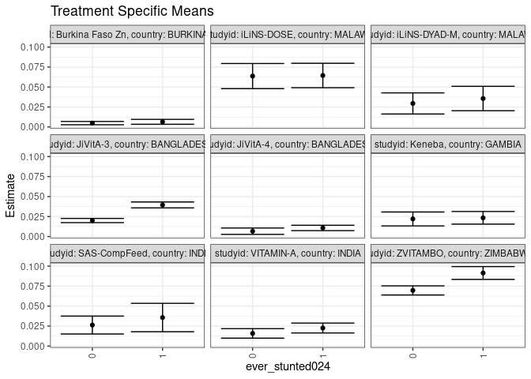

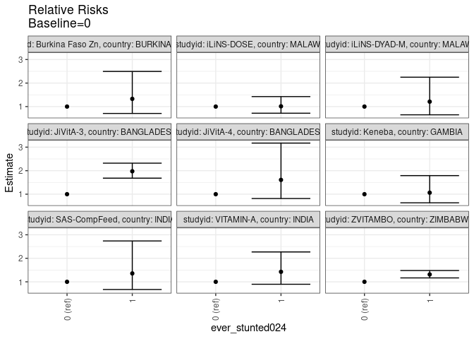

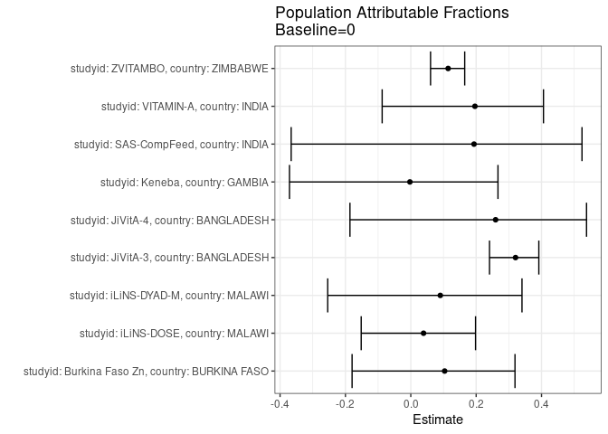

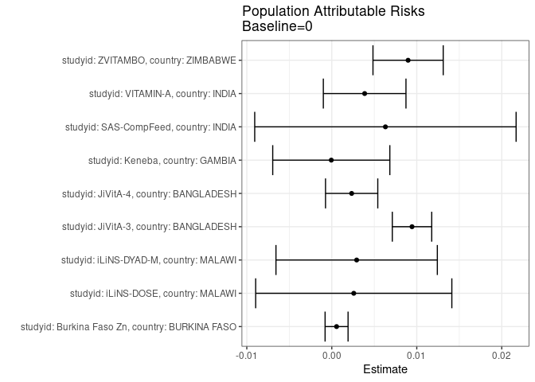

## Results Table

### Parameter: TSM

| studyid | country | intervention_level | baseline_level | estimate | ci_lower | ci_upper |
| --- | --- | --- | --- | --- | --- | --- |
| Burkina Faso Zn | BURKINA FASO | 0 | NA | 0.0048799 | 0.0028498 | 0.0069101 |
| Burkina Faso Zn | BURKINA FASO | 1 | NA | 0.0064837 | 0.0034154 | 0.0095520 |
| iLiNS-DOSE | MALAWI | 0 | NA | 0.0637023 | 0.0479876 | 0.0794171 |
| iLiNS-DOSE | MALAWI | 1 | NA | 0.0644253 | 0.0491299 | 0.0797207 |
| iLiNS-DYAD-M | MALAWI | 0 | NA | 0.0294664 | 0.0162446 | 0.0426882 |
| iLiNS-DYAD-M | MALAWI | 1 | NA | 0.0356311 | 0.0203522 | 0.0509101 |
| JiVitA-3 | BANGLADESH | 0 | NA | 0.0200160 | 0.0173875 | 0.0226445 |
| JiVitA-3 | BANGLADESH | 1 | NA | 0.0395288 | 0.0358364 | 0.0432212 |
| JiVitA-4 | BANGLADESH | 0 | NA | 0.0066674 | 0.0026848 | 0.0106500 |
| JiVitA-4 | BANGLADESH | 1 | NA | 0.0107255 | 0.0073578 | 0.0140932 |
| Keneba | GAMBIA | 0 | NA | 0.0220152 | 0.0133213 | 0.0307092 |
| Keneba | GAMBIA | 1 | NA | 0.0234284 | 0.0155127 | 0.0313440 |
| SAS-CompFeed | INDIA | 0 | NA | 0.0263053 | 0.0150981 | 0.0375126 |
| SAS-CompFeed | INDIA | 1 | NA | 0.0356866 | 0.0179245 | 0.0534487 |
| VITAMIN-A | INDIA | 0 | NA | 0.0158411 | 0.0098904 | 0.0217918 |
| VITAMIN-A | INDIA | 1 | NA | 0.0225802 | 0.0163768 | 0.0287836 |
| ZVITAMBO | ZIMBABWE | 0 | NA | 0.0696060 | 0.0639027 | 0.0753093 |
| ZVITAMBO | ZIMBABWE | 1 | NA | 0.0914036 | 0.0833903 | 0.0994170 |

### Parameter: E(Y)

| studyid | country | intervention_level | baseline_level | estimate | ci_lower | ci_upper |
| --- | --- | --- | --- | --- | --- | --- |
| Burkina Faso Zn | BURKINA FASO | NA | NA | 0.0054439 | 0.0037399 | 0.0071479 |
| iLiNS-DOSE | MALAWI | NA | NA | 0.0662869 | 0.0551877 | 0.0773861 |
| iLiNS-DYAD-M | MALAWI | NA | NA | 0.0323920 | 0.0223878 | 0.0423963 |
| JiVitA-3 | BANGLADESH | NA | NA | 0.0294561 | 0.0273691 | 0.0315430 |
| JiVitA-4 | BANGLADESH | NA | NA | 0.0090040 | 0.0064549 | 0.0115532 |
| Keneba | GAMBIA | NA | NA | 0.0219554 | 0.0166349 | 0.0272759 |
| SAS-CompFeed | INDIA | NA | NA | 0.0326158 | 0.0204960 | 0.0447355 |
| VITAMIN-A | INDIA | NA | NA | 0.0197082 | 0.0153493 | 0.0240672 |
| ZVITAMBO | ZIMBABWE | NA | NA | 0.0785846 | 0.0741388 | 0.0830304 |

### Parameter: RR

| studyid | country | intervention_level | baseline_level | estimate | ci_lower | ci_upper |
| --- | --- | --- | --- | --- | --- | --- |
| Burkina Faso Zn | BURKINA FASO | 0 | 0 | 1.000000 | 1.0000000 | 1.000000 |
| Burkina Faso Zn | BURKINA FASO | 1 | 0 | 1.328639 | 0.7075148 | 2.495046 |
| iLiNS-DOSE | MALAWI | 0 | 0 | 1.000000 | 1.0000000 | 1.000000 |
| iLiNS-DOSE | MALAWI | 1 | 0 | 1.011349 | 0.7181290 | 1.424294 |
| iLiNS-DYAD-M | MALAWI | 0 | 0 | 1.000000 | 1.0000000 | 1.000000 |
| iLiNS-DYAD-M | MALAWI | 1 | 0 | 1.209213 | 0.6500491 | 2.249364 |
| JiVitA-3 | BANGLADESH | 0 | 0 | 1.000000 | 1.0000000 | 1.000000 |
| JiVitA-3 | BANGLADESH | 1 | 0 | 1.974861 | 1.6815527 | 2.319331 |
| JiVitA-4 | BANGLADESH | 0 | 0 | 1.000000 | 1.0000000 | 1.000000 |
| JiVitA-4 | BANGLADESH | 1 | 0 | 1.608645 | 0.8153950 | 3.173603 |
| Keneba | GAMBIA | 0 | 0 | 1.000000 | 1.0000000 | 1.000000 |
| Keneba | GAMBIA | 1 | 0 | 1.064189 | 0.6327890 | 1.789693 |
| SAS-CompFeed | INDIA | 0 | 0 | 1.000000 | 1.0000000 | 1.000000 |
| SAS-CompFeed | INDIA | 1 | 0 | 1.356630 | 0.6723160 | 2.737469 |
| VITAMIN-A | INDIA | 0 | 0 | 1.000000 | 1.0000000 | 1.000000 |
| VITAMIN-A | INDIA | 1 | 0 | 1.425420 | 0.8950512 | 2.270062 |
| ZVITAMBO | ZIMBABWE | 0 | 0 | 1.000000 | 1.0000000 | 1.000000 |
| ZVITAMBO | ZIMBABWE | 1 | 0 | 1.313158 | 1.1654978 | 1.479525 |

### Parameter: PAR

| studyid | country | intervention_level | baseline_level | estimate | ci_lower | ci_upper |
| --- | --- | --- | --- | --- | --- | --- |
| Burkina Faso Zn | BURKINA FASO | 0 | NA | 0.0005639 | -0.0007878 | 0.0019157 |
| iLiNS-DOSE | MALAWI | 0 | NA | 0.0025846 | -0.0089572 | 0.0141263 |
| iLiNS-DYAD-M | MALAWI | 0 | NA | 0.0029256 | -0.0065690 | 0.0124203 |
| JiVitA-3 | BANGLADESH | 0 | NA | 0.0094401 | 0.0071207 | 0.0117595 |
| JiVitA-4 | BANGLADESH | 0 | NA | 0.0023366 | -0.0007381 | 0.0054114 |
| Keneba | GAMBIA | 0 | NA | -0.0000598 | -0.0069499 | 0.0068302 |
| SAS-CompFeed | INDIA | 0 | NA | 0.0063104 | -0.0090687 | 0.0216896 |
| VITAMIN-A | INDIA | 0 | NA | 0.0038671 | -0.0009947 | 0.0087289 |
| ZVITAMBO | ZIMBABWE | 0 | NA | 0.0089786 | 0.0048454 | 0.0131118 |

### Parameter: PAF

| studyid | country | intervention_level | baseline_level | estimate | ci_lower | ci_upper |
| --- | --- | --- | --- | --- | --- | --- |
| Burkina Faso Zn | BURKINA FASO | 0 | NA | 0.1035924 | -0.1796344 | 0.3188173 |
| iLiNS-DOSE | MALAWI | 0 | NA | 0.0389910 | -0.1517561 | 0.1981476 |
| iLiNS-DYAD-M | MALAWI | 0 | NA | 0.0903199 | -0.2542341 | 0.3402205 |
| JiVitA-3 | BANGLADESH | 0 | NA | 0.3204797 | 0.2408362 | 0.3917678 |
| JiVitA-4 | BANGLADESH | 0 | NA | 0.2595094 | -0.1861471 | 0.5377248 |
| Keneba | GAMBIA | 0 | NA | -0.0027249 | -0.3712053 | 0.2667348 |
| SAS-CompFeed | INDIA | 0 | NA | 0.1934784 | -0.3660402 | 0.5238228 |
| VITAMIN-A | INDIA | 0 | NA | 0.1962180 | -0.0876220 | 0.4059834 |
| ZVITAMBO | ZIMBABWE | 0 | NA | 0.1142544 | 0.0604523 | 0.1649756 |